# Real Estate Analysis

```python
from pathlib import Path

import pandas as pd
import numpy as np
import matplotlib.pyplot as plt
import calendar
```

```python
BASE_DIR = Path().resolve().parents[0]
file_path = BASE_DIR / "data/clean/dvf_clean.parquet"
```

```python
df = pd.read_parquet(file_path)
```

```python
df.shape
```

```
(465206, 18)
```

```python
df.info(show_counts=True)
```

```
<class 'pandas.DataFrame'>
RangeIndex: 465206 entries, 0 to 465205
Data columns (total 18 columns):
 #   Column                     Non-Null Count   Dtype
---  ------                     --------------   -----
 0   Date mutation              465206 non-null  datetime64[us]
 1   Nature mutation            465206 non-null  category
 2   Valeur fonciere            465206 non-null  float64
 3   No voie                    461241 non-null  float64
 4   Type de voie               450313 non-null  str
 5   Code voie                  465206 non-null  str
 6   Voie                       465205 non-null  str
 7   Code postal                465206 non-null  str
 8   Commune                    465206 non-null  category
 9   Code departement           465206 non-null  str
 10  Code commune               465206 non-null  int64
 11  Section                    465180 non-null  str
 12  No plan                    465206 non-null  int64
 13  Code type local            465206 non-null  float64
 14  Type local                 465206 non-null  category
 15  Surface reelle bati        465206 non-null  float64
 16  Nombre pieces principales  465206 non-null  float64
 17  prix_m2                    465206 non-null  float64
dtypes: category(3), datetime64[us](1), float64(6), int64(2), str(6)
memory usage: 68.2 MB
```

```python
df.head()
```

|  | Date mutation | Nature mutation | Valeur fonciere | No voie | Type de voie | Code voie | Voie | Code postal | Commune | Code departement | Code commune | Section | No plan | Code type local | Type local | Surface reelle bati | Nombre pieces principales | prix_m2 |
| --- | --- | --- | --- | --- | --- | --- | --- | --- | --- | --- | --- | --- | --- | --- | --- | --- | --- | --- |
| 0 | 2025-01-09 | Vente | 183000.0 | 250.0 | AV | 0041 | DE BELLE FERME | 1170 | GEX | 01 | 173 | AH | 194 | 2.0 | Appartement | 35.0 | 2.0 | 5228.571429 |
| 1 | 2025-01-08 | Vente | 131937.3 | 62.0 | CHE | 0950 | DU PEUPLE | 1330 | AMBERIEUX-EN-DOMBES | 01 | 5 | AC | 291 | 2.0 | Appartement | 49.0 | 2.0 | 2692.597959 |
| 2 | 2025-01-09 | Vente | 173000.0 | 5338.0 | NaN | B006 | GRAND FAUBOURG | 1290 | PONT-DE-VEYLE | 01 | 306 | A | 1294 | 2.0 | Appartement | 78.0 | 3.0 | 2217.948718 |
| 3 | 2025-01-06 | Vente | 414665.0 | 124.0 | CHE | 0032 | DE CHAMP JOURNET | 1630 | CHALLEX | 01 | 78 | B | 218 | 2.0 | Appartement | 67.0 | 3.0 | 6189.029851 |
| 4 | 2025-01-10 | Vente | 259000.0 | 85.0 | RUE | 0101 | DE CHATEAU GAGNEUR | 1170 | GEX | 01 | 173 | AB | 236 | 2.0 | Appartement | 48.0 | 2.0 | 5395.833333 |

### Overall analysis of the "`prix_m2`"

```python
df["prix_m2"].describe()
```

```
count    465206.000000
mean       6840.525667
std       18489.588594
min         161.538462
25%        2210.526316
50%        3442.857143
75%        5500.000000
max      324871.965986
Name: prix_m2, dtype: float64
```

- Right-skewed distribution with a heavy tail
  - Some very high values pull the average upwards
- Median represents the real market
- Average is skewed by premium zones ("`prix_m2`" by city)

#### Distribution of "`prix_m2`"

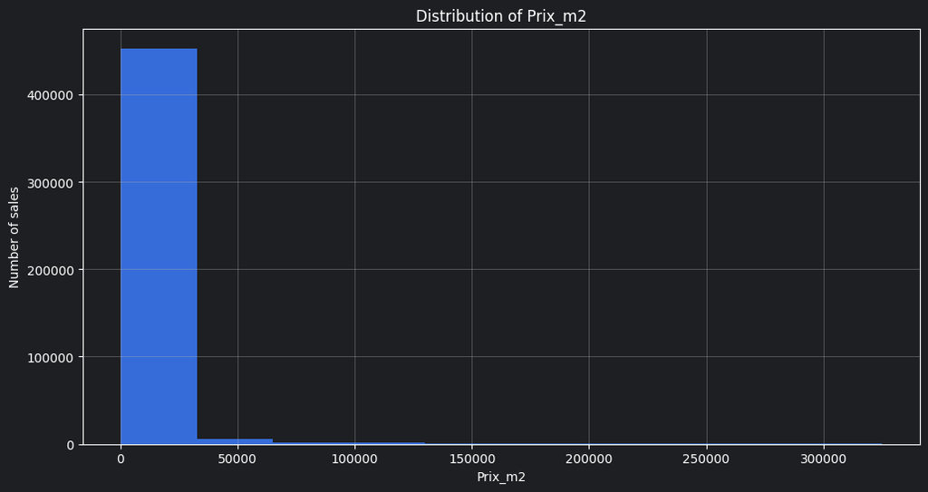

```python
plt.figure(figsize=(12, 6))

df["prix_m2"].hist(bins=10)

plt.title("Distribution of Prix_m2")
plt.xlabel("Prix_m2")
plt.ylabel("Number of sales")

plt.show()
```

##### Distribution (heavy tail)

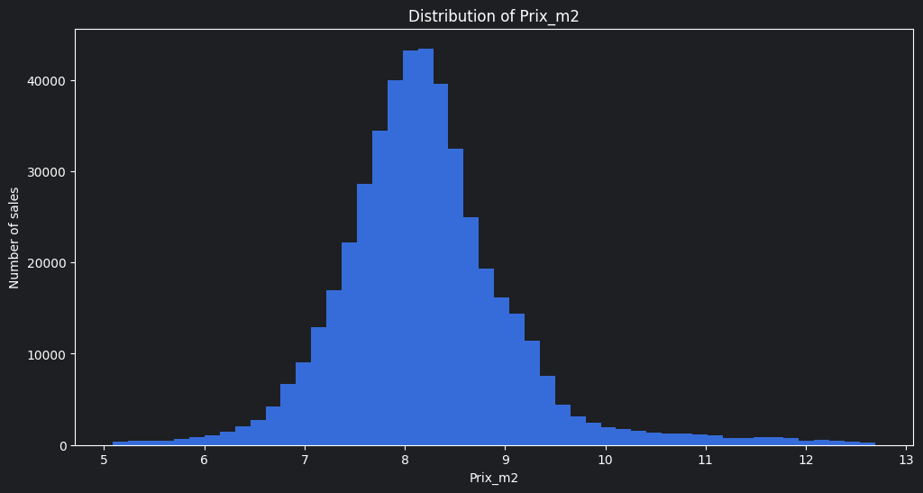

```python
plt.figure(figsize=(12, 6))

plt.hist(np.log1p(df["prix_m2"]), bins=50)

plt.title("Distribution of Prix_m2")
plt.xlabel("Prix_m2")
plt.ylabel("Number of sales")

plt.show()
```

#### Boxplot of "`prix_m2`"

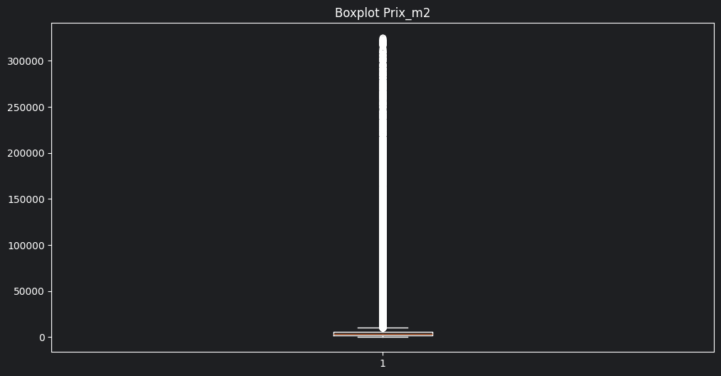

```python
plt.figure(figsize=(12, 6))
plt.boxplot(df["prix_m2"])
plt.title("Boxplot Prix_m2")
plt.show()
```

### "`prix_m2`" by property type

```python
df.groupby("Type local")["prix_m2"].describe()
```

| Type local | count | mean | std | min | 25% | 50% | 75% | max |
| --- | --- | --- | --- | --- | --- | --- | --- | --- |
| Appartement | 392951.0 | 5497.315550 | 12758.226681 | 161.538462 | 2264.433908 | 3452.830189 | 5348.837209 | 323620.689655 |
| Local industriel. commercial ou assimilé | 48167.0 | 18630.078048 | 40263.896773 | 162.037037 | 1816.326531 | 3800.000000 | 12551.176471 | 324871.965986 |
| Maison | 24088.0 | 5177.805197 | 19880.046306 | 163.469027 | 1973.596491 | 3016.760300 | 4363.573565 | 306250.000000 |

- Market dominated by apartments (Appartement > Local > Maison)
- Very heterogeneous market (premium and rural areas, expensive cities)
- Commercial premises dominate in average value but are very unstable.
- Houses and apartments are close in median price: homogeneous residential market.
- High presence of outliers: the average is not reliable.

```python
median_by_type = (
    df.groupby("Type local")["prix_m2"]
    .median()
    .sort_values(ascending=False)
)
```

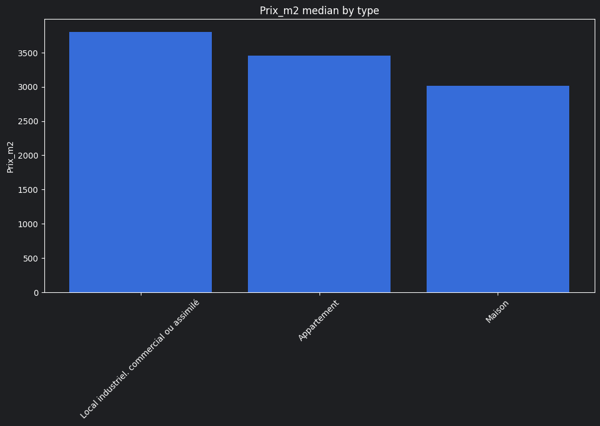

```python
plt.figure(figsize=(12, 6))

plt.bar(
    median_by_type.index,
    median_by_type.values
)

plt.title("Prix_m2 median by type")
plt.ylabel("Prix_m2")
plt.xticks(rotation=45)
plt.show()
```

### Prix_m2 by city

```python
df["Commune"] = df["Commune"].cat.remove_unused_categories()
```

```python
city_counts = df["Commune"].value_counts()
print(len(city_counts))
```

```
9490
```

```python
treshold_city_count = city_counts.quantile(0.99)
valid_cities = city_counts[city_counts >= treshold_city_count].index

df_city = df[df["Commune"].isin(valid_cities)]
print(len(valid_cities))
```

```
95
```

```python
city_prices = (
    df_city.groupby("Commune")["prix_m2"]
    .median()
    .sort_values(ascending=False)
)

city_prices.sort_values(ascending=False).head(20)
```

```
Commune
PARIS 06                15000.000000
PARIS 07                14384.166667
PARIS 08                12500.000000
PARIS 05                12095.238095
PARIS 03                12000.000000
PARIS 09                11157.894737
PARIS 16                11100.000000
NEUILLY-SUR-SEINE       10654.761905
PARIS 17                10297.150000
PARIS 11                10000.000000
PARIS 14                 9594.594595
PARIS 15                 9552.238806
PARIS 10                 9375.000000
LEVALLOIS-PERRET         9266.410408
PARIS 12                 9071.428571
PARIS 18                 9000.000000
PARIS 13                 8690.981432
VINCENNES                8658.155080
PARIS 20                 8407.206633
BOULOGNE-BILLANCOURT     8333.333333
Name: prix_m2, dtype: float64
```

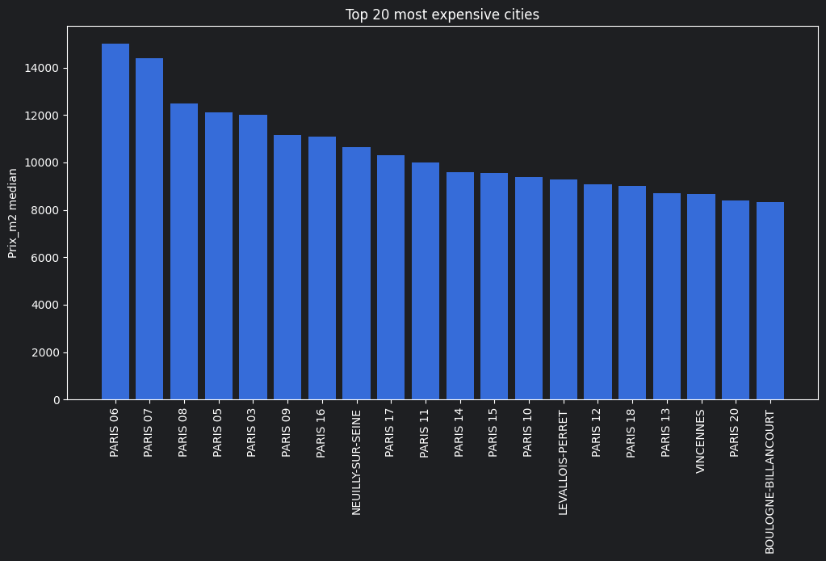

```python
top_cities = city_prices.head(20)

plt.figure(figsize=(12, 6))

plt.bar(top_cities.index, top_cities.values)

plt.xticks(rotation=90)
plt.ylabel("Prix_m2 median")
plt.title("Top 20 most expensive cities")

plt.show()
```

### Prix_m2 by `departement`

```python
dept_counts = df["Code departement"].value_counts()
```

```python
treshold_dept_count = dept_counts.quantile(0.9)
valid_dept = dept_counts[dept_counts >= treshold_dept_count].index

df_dept = df[df["Code departement"].isin(valid_dept)]
print(len(valid_dept))
```

```
10
```

```python
dept_prices = (
    df_dept.groupby("Code departement")["prix_m2"]
    .median()
    .sort_values(ascending=False)
)

dept_prices.sort_values(ascending=False).head(20)
```

```
Code departement
75    9956.140351
92    6575.662021
06    4938.434048
94    4852.941176
93    4250.000000
69    3909.090909
83    3850.574713
34    3460.495716
13    3453.488372
31    2985.347826
Name: prix_m2, dtype: float64
```

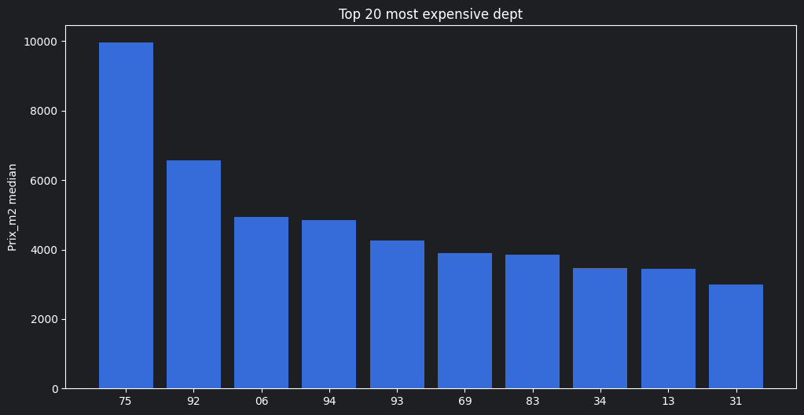

```python
top_dept = dept_prices.head(20)

plt.figure(figsize=(12, 6))

plt.bar(top_dept.index, top_dept.values)

plt.ylabel("Prix_m2 median")
plt.title("Top 20 most expensive dept")

plt.show()
```

### Temporal analysis

```python
monthly_transactions = (
    df["Date mutation"]
    .dt.month
    .value_counts()
    .sort_index()
)
print(monthly_transactions)
```

```
Date mutation
1     32807
2     32709
3     43031
4     39361
5     31745
6     43174
7     50375
8     27474
9     44338
10    40759
11    32893
12    46540
Name: count, dtype: int64
```

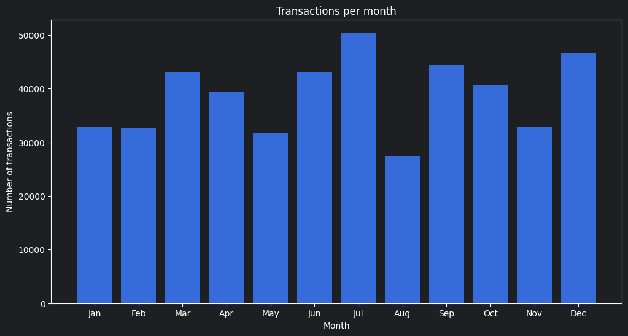

```python
months = range(1, 13)
month_names = [calendar.month_abbr[m] for m in months]

plt.figure(figsize=(12, 6))

plt.bar(
    monthly_transactions.index,
    monthly_transactions.values
)

plt.title("Transactions per month")
plt.xlabel("Month")
plt.xticks(months, month_names)
plt.ylabel("Number of transactions")

plt.show()
```

- Volumes vary greatly: up to 80% difference between months
- Low activity on August, May and February
- High activity on July, December and September
- **Seasonality** which can be explain by families buying before the start of the school year and house moving in summer

```python
monthly_prices = (
    df.groupby(df["Date mutation"].dt.month)["prix_m2"]
    .median()
)
print(monthly_prices)
```

```
Date mutation
1     3395.348837
2     3315.000000
3     3512.884375
4     3265.306122
5     3350.000000
6     3480.000000
7     3513.698630
8     3309.307359
9     3553.191489
10    3449.285714
11    3428.571429
12    3615.384615
Name: prix_m2, dtype: float64
```

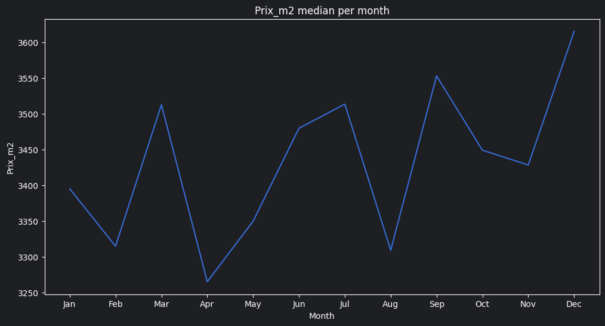

```python
plt.figure(figsize=(12, 6))

plt.plot(
    monthly_prices.index,
    monthly_prices.values
)

plt.title("Prix_m2 median per month")
plt.xlabel("Month")
plt.xticks(months, month_names)
plt.ylabel("Prix_m2")

plt.show()
```

- No strong seasonality
  - Months slightly more expensive : December, September, July and March
  - Months slightly cheaper : April, August and February

The price/m² (`prix_m2`) remains generally stable throughout the year, with limited variations (~10%). This suggests a lack of strong seasonality in real estate prices, contrary to the transaction volume, which is highly seasonal.

### `Surface reelle bati` analysis

```python
df["Surface reelle bati"].describe()
```

```
count    465206.000000
mean         63.518044
std         108.991032
min           1.000000
25%          36.000000
50%          55.000000
75%          74.000000
max       22511.000000
Name: Surface reelle bati, dtype: float64
```

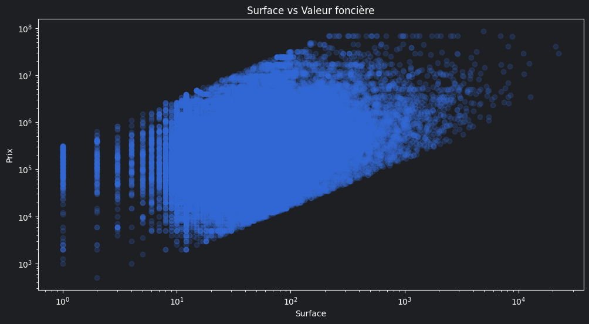

```python
plt.figure(figsize=(12, 6))

plt.scatter(
    df["Surface reelle bati"],
    df["Valeur fonciere"],
    alpha=0.2
)

plt.title("Surface vs Valeur foncière")
plt.xlabel("Surface")
plt.ylabel("Prix")

plt.xscale("log")
plt.yscale("log")

plt.show()
```

### Correlations

```python
numeric_cols = df[["Valeur fonciere", "Surface reelle bati", "Nombre pieces principales", "prix_m2"]]

print(numeric_cols.corr(method="spearman"))
```

```
                           Valeur fonciere  Surface reelle bati  \
Valeur fonciere                   1.000000             0.374550
Surface reelle bati               0.374550             1.000000
Nombre pieces principales         0.247157             0.689095
prix_m2                           0.702218            -0.304374

                           Nombre pieces principales   prix_m2
Valeur fonciere                             0.247157  0.702218
Surface reelle bati                         0.689095 -0.304374
Nombre pieces principales                   1.000000 -0.200205
prix_m2                                    -0.200205  1.000000
```

- 1st factor : price/m² (`prix_m2`)
- 2nd factor : `Surface reelle bati`
- 3rd factor : number of rooms (`Nombre pieces principales`)

Real estate value is mainly correlated with the price/m², while area plays a secondary role. The number of rooms explains very little in price variations, which highlights the importance of the location and positioning of the property in the real estate market.

### Top transactions

```python
df.sort_values(
    by="Valeur fonciere",
    ascending=False
)[[
    "Commune",
    "Type local",
    "Valeur fonciere",
    "Surface reelle bati",
    "prix_m2"
]].head(20)
```

|  | Commune | Type local | Valeur fonciere | Surface reelle bati | prix_m2 |
| --- | --- | --- | --- | --- | --- |
| 445421 | PARIS 04 | Local industriel. commercial ou assimilé | 85575112.8 | 4929.0 | 17361.556665 |
| 330325 | AMIENS | Local industriel. commercial ou assimilé | 69000000.0 | 519.0 | 132947.976879 |
| 330344 | AMIENS | Local industriel. commercial ou assimilé | 69000000.0 | 504.0 | 136904.761905 |
| 330348 | AMIENS | Local industriel. commercial ou assimilé | 69000000.0 | 2064.0 | 33430.232558 |
| 330322 | AMIENS | Local industriel. commercial ou assimilé | 69000000.0 | 372.0 | 185483.870968 |
| 330337 | AMIENS | Local industriel. commercial ou assimilé | 69000000.0 | 2530.0 | 27272.727273 |
| 330336 | AMIENS | Local industriel. commercial ou assimilé | 69000000.0 | 1723.0 | 40046.430644 |
| 330323 | AMIENS | Local industriel. commercial ou assimilé | 69000000.0 | 350.0 | 197142.857143 |
| 330335 | AMIENS | Local industriel. commercial ou assimilé | 69000000.0 | 1165.0 | 59227.467811 |
| 330341 | AMIENS | Local industriel. commercial ou assimilé | 69000000.0 | 2642.0 | 26116.578350 |
| 330338 | AMIENS | Local industriel. commercial ou assimilé | 69000000.0 | 461.0 | 149674.620390 |
| 330330 | AMIENS | Local industriel. commercial ou assimilé | 69000000.0 | 964.0 | 71576.763485 |
| 330329 | AMIENS | Local industriel. commercial ou assimilé | 69000000.0 | 320.0 | 215625.000000 |
| 330328 | AMIENS | Local industriel. commercial ou assimilé | 69000000.0 | 567.0 | 121693.121693 |
| 330327 | AMIENS | Local industriel. commercial ou assimilé | 69000000.0 | 6913.0 | 9981.194850 |
| 330332 | AMIENS | Local industriel. commercial ou assimilé | 69000000.0 | 965.0 | 71502.590674 |
| 330333 | AMIENS | Local industriel. commercial ou assimilé | 69000000.0 | 321.0 | 214953.271028 |
| 330331 | AMIENS | Local industriel. commercial ou assimilé | 69000000.0 | 1352.0 | 51035.502959 |
| 330326 | AMIENS | Local industriel. commercial ou assimilé | 69000000.0 | 511.0 | 135029.354207 |
| 330345 | AMIENS | Local industriel. commercial ou assimilé | 69000000.0 | 390.0 | 176923.076923 |

### Detection of atypical real estate

#### Very expensive `prix_m2`

```python
top_quantile = df["prix_m2"].quantile(0.9)
```

```python
df[df["prix_m2"] > top_quantile][[
    "Commune",
    "Type local",
    "Valeur fonciere",
    "Surface reelle bati",
    "prix_m2"
]].head(20)
```

|  | Commune | Type local | Valeur fonciere | Surface reelle bati | prix_m2 |
| --- | --- | --- | --- | --- | --- |
| 87 | FERNEY-VOLTAIRE | Local industriel. commercial ou assimilé | 135000.0 | 12.0 | 11250.000000 |
| 93 | MIRIBEL | Maison | 7788138.5 | 220.0 | 35400.629545 |
| 101 | BOURG-EN-BRESSE | Local industriel. commercial ou assimilé | 160000.0 | 9.0 | 17777.777778 |
| 141 | CHAZEY-SUR-AIN | Local industriel. commercial ou assimilé | 510000.0 | 27.0 | 18888.888889 |
| 143 | CHAZEY-SUR-AIN | Local industriel. commercial ou assimilé | 510000.0 | 30.0 | 17000.000000 |
| 144 | CHAZEY-SUR-AIN | Local industriel. commercial ou assimilé | 510000.0 | 21.0 | 24285.714286 |
| 146 | CHAZEY-SUR-AIN | Appartement | 510000.0 | 26.0 | 19615.384615 |
| 148 | SAINT-MAURICE-DE-BEYNOST | Appartement | 152900.0 | 1.0 | 152900.000000 |
| 180 | VALSERHONE | Appartement | 400000.0 | 39.0 | 10256.410256 |
| 182 | VALSERHONE | Appartement | 400000.0 | 35.0 | 11428.571429 |
| 183 | VALSERHONE | Appartement | 400000.0 | 37.0 | 10810.810811 |
| 205 | BOURG-EN-BRESSE | Appartement | 410000.0 | 13.0 | 31538.461538 |
| 206 | BOURG-EN-BRESSE | Appartement | 410000.0 | 24.0 | 17083.333333 |
| 208 | BOURG-EN-BRESSE | Appartement | 410000.0 | 37.0 | 11081.081081 |
| 209 | BOURG-EN-BRESSE | Appartement | 410000.0 | 28.0 | 14642.857143 |
| 235 | DIVONNE-LES-BAINS | Local industriel. commercial ou assimilé | 562604.0 | 22.0 | 25572.909091 |
| 236 | DIVONNE-LES-BAINS | Local industriel. commercial ou assimilé | 562604.0 | 22.0 | 25572.909091 |
| 237 | DIVONNE-LES-BAINS | Local industriel. commercial ou assimilé | 562604.0 | 22.0 | 25572.909091 |
| 238 | DIVONNE-LES-BAINS | Local industriel. commercial ou assimilé | 562604.0 | 22.0 | 25572.909091 |
| 239 | DIVONNE-LES-BAINS | Local industriel. commercial ou assimilé | 562604.0 | 22.0 | 25572.909091 |

#### Very low `prix_m2`

```python
bottom_quantile = df["prix_m2"].quantile(q=0.1)
```

```python
df[df["prix_m2"] < bottom_quantile][[
    "Commune",
    "Type local",
    "Valeur fonciere",
    "Surface reelle bati",
    "prix_m2"
]].head(20)
```

|  | Commune | Type local | Valeur fonciere | Surface reelle bati | prix_m2 |
| --- | --- | --- | --- | --- | --- |
| 6 | OYONNAX | Appartement | 65000.0 | 49.0 | 1326.530612 |
| 18 | ROMANS | Appartement | 100000.0 | 81.0 | 1234.567901 |
| 33 | VONNAS | Appartement | 47000.0 | 139.0 | 338.129496 |
| 34 | ROMANS | Appartement | 94000.0 | 69.0 | 1362.318841 |
| 36 | BOURG-EN-BRESSE | Appartement | 95000.0 | 69.0 | 1376.811594 |
| 40 | VALSERHONE | Local industriel. commercial ou assimilé | 110000.0 | 113.0 | 973.451327 |
| 55 | SAINT-DIDIER-SUR-CHALARONNE | Appartement | 45000.0 | 48.0 | 937.500000 |
| 60 | BOURG-EN-BRESSE | Appartement | 117000.0 | 100.0 | 1170.000000 |
| 65 | OYONNAX | Appartement | 82000.0 | 68.0 | 1205.882353 |
| 75 | ST-GENIS-POUILLY | Local industriel. commercial ou assimilé | 25000.0 | 69.0 | 362.318841 |
| 79 | DOMPIERRE-SUR-VEYLE | Appartement | 95500.0 | 86.0 | 1110.465116 |
| 80 | BOURG-EN-BRESSE | Appartement | 95000.0 | 84.0 | 1130.952381 |
| 86 | FERNEY-VOLTAIRE | Local industriel. commercial ou assimilé | 8000.0 | 12.0 | 666.666667 |
| 99 | MANZIAT | Local industriel. commercial ou assimilé | 29000.0 | 75.0 | 386.666667 |
| 103 | BOURG-EN-BRESSE | Local industriel. commercial ou assimilé | 40000.0 | 35.0 | 1142.857143 |
| 105 | BOURG-EN-BRESSE | Appartement | 90000.0 | 69.0 | 1304.347826 |
| 112 | FEILLENS | Maison | 140000.0 | 140.0 | 1000.000000 |
| 120 | BELLEY | Appartement | 108000.0 | 104.0 | 1038.461538 |
| 134 | BOURG-EN-BRESSE | Appartement | 92000.0 | 70.0 | 1314.285714 |
| 135 | OYONNAX | Local industriel. commercial ou assimilé | 130000.0 | 138.0 | 942.028986 |

## Core market

```python
q10 = df["prix_m2"].quantile(0.1)
q90 = df["prix_m2"].quantile(0.9)

df_core = df[
    (df["prix_m2"] >= q10) &
    (df["prix_m2"] <= q90)
]
```

### New overall analysis of the "`prix_m2`"

```python
print(df_core["prix_m2"].describe())
```

```
count    372196.000000
mean       3919.629208
std        1924.945387
min        1411.764706
25%        2452.830189
50%        3442.994025
75%        4895.833333
max        9800.000000
Name: prix_m2, dtype: float64
```

- The distribution remains asymmetrical on the right
- Median represents the real market

**Before and after 'Core market'**

|  | Before | After |
| --- | --- | --- |
| **Mean** | 6840 | 3919 |
| **Std** | 18489 | 1924 |
| **Max** | 324871 | 9800 |

After removing extreme outliers, the price-per-square-meter (`price_m2`) distribution becomes significantly more stable and representative of the standard residential real estate market. The mean and median are now much closer, indicating a substantial reduction in skewness caused by luxury or anomalous transactions.

#### Distribution of "`prix_m2`"

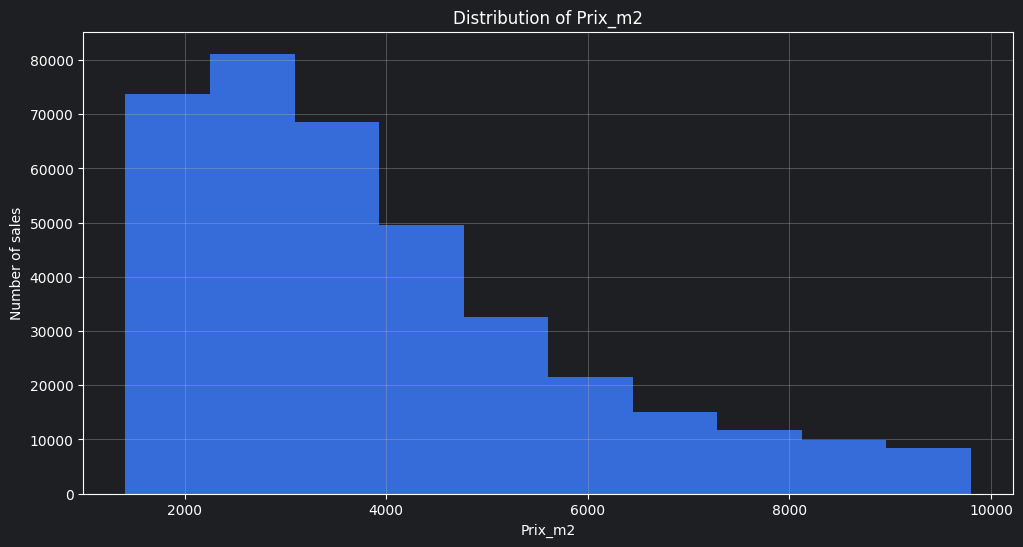

```python
plt.figure(figsize=(12, 6))

df_core["prix_m2"].hist(bins=10)

plt.title("Distribution of Prix_m2")
plt.xlabel("Prix_m2")
plt.ylabel("Number of sales")

plt.show()
```

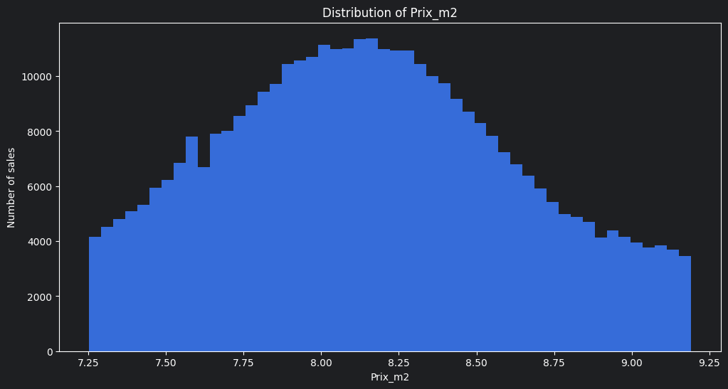

```python
plt.figure(figsize=(12, 6))

plt.hist(np.log1p(df_core["prix_m2"]), bins=50)

plt.title("Distribution of Prix_m2")
plt.xlabel("Prix_m2")
plt.ylabel("Number of sales")

plt.show()
```

#### Boxplot of "`prix_m2`"

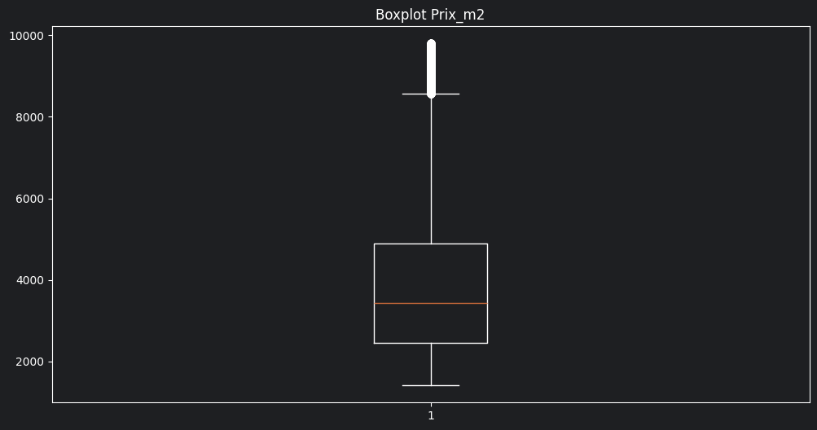

```python
plt.figure(figsize=(12, 6))

plt.boxplot(df_core["prix_m2"])

plt.title("Boxplot Prix_m2")

plt.show()
```

### "`prix_m2`" by property type

```python
print(df_core.groupby("Type local")["prix_m2"].describe())
```

```
                                             count         mean          std  \
Type local
Appartement                               326470.0  3944.307760  1926.383442
Local industriel. commercial ou assimilé   25633.0  3876.291437  2091.860470
Maison                                     20093.0  3573.940166  1621.313799

                                                  min          25%  \
Type local
Appartement                               1411.764706  2483.050847
Local industriel. commercial ou assimilé  1411.764706  2205.882353
Maison                                    1411.764706  2348.484848

                                                  50%          75%  \
Type local
Appartement                               3472.222222  4918.297146
Local industriel. commercial ou assimilé  3231.578947  5063.291139
Maison                                    3223.272727  4401.408451

                                                  max
Type local
Appartement                               9800.000000
Local industriel. commercial ou assimilé  9800.000000
Maison                                    9793.814433
```

```python
median_by_type = (
    df_core.groupby("Type local")["prix_m2"]
    .median()
    .sort_values(ascending=False)
)
```

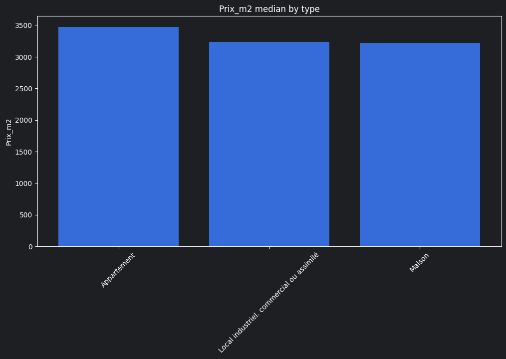

```python
plt.figure(figsize=(12, 6))

plt.bar(
    median_by_type.index,
    median_by_type.values
)

plt.title("Prix_m2 median by type")
plt.ylabel("Prix_m2")
plt.xticks(rotation=45)
plt.show()
```

### Top city (volume)

```python
top_city = df_core["Commune"].value_counts().head(10)
print(top_city)
```

```
Commune
NICE           7818
TOULOUSE       7441
MONTPELLIER    4791
NANTES         4475
BORDEAUX       3770
RENNES         3168
TOULON         2852
LILLE          2843
DIJON          2797
GRENOBLE       2398
Name: count, dtype: int64
```

```python
df_core_top_city = df_core[df_core["Commune"].isin(top_city.index)]

top_city_prices = (
    df_core_top_city.groupby("Commune")["prix_m2"]
    .median()
    .sort_values(ascending=False)
)

top_city_prices.sort_values(ascending=False).head(20)
```

```
Commune
NICE           4785.714286
BORDEAUX       4126.829787
LILLE          3754.545455
RENNES         3709.384164
MONTPELLIER    3507.462687
NANTES         3415.000000
TOULOUSE       3313.043478
DIJON          2796.610169
TOULON         2760.760073
GRENOBLE       2619.047619
Name: prix_m2, dtype: float64
```

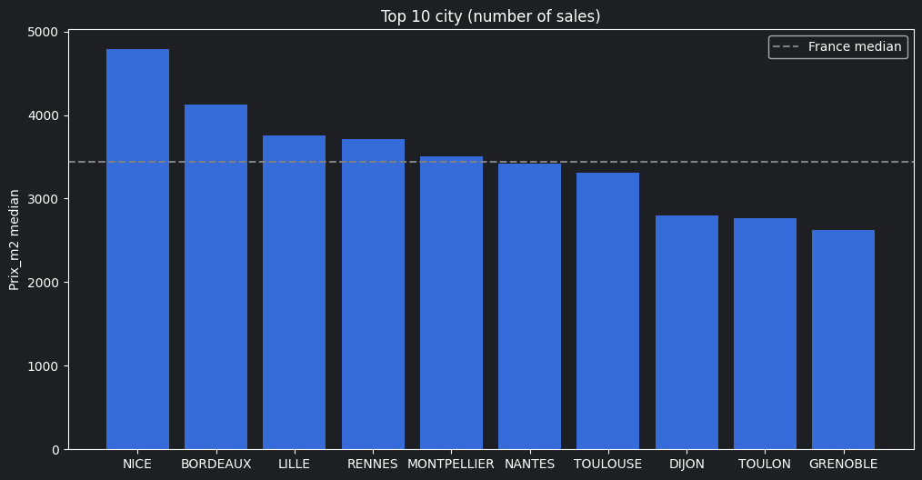

```python
plt.figure(figsize=(12, 6))

plt.bar(top_city_prices.index, top_city_prices.values)

plt.axhline(df_core["prix_m2"].median(), label="France median" ,color="grey", linestyle="dashed")

plt.ylabel("Prix_m2 median")
plt.title("Top 10 city (number of sales)")

plt.legend(loc="upper right")

plt.show()
```

### Prix_m2 by city

```python
city_counts = df_core["Commune"].value_counts()
print(len(city_counts))
```

```
9490
```

```python
treshold_city_count = city_counts.quantile(0.9)
valid_cities = city_counts[city_counts >= treshold_city_count].index

df_core_city = df_core[df_core["Commune"].isin(valid_cities)]
print(len(valid_cities))
```

```
955
```

```python
city_prices = (
    df_core_city.groupby("Commune")["prix_m2"]
    .median()
    .sort_values(ascending=False)
)

print(city_prices.sort_values(ascending=False).head(20))
```

```
Commune
NEUILLY-SUR-SEINE      8666.666667
PARIS 11               8535.897436
PARIS 16               8500.000000
LEVALLOIS-PERRET       8427.947598
PARIS 15               8424.242424
PARIS 14               8387.096774
PARIS 12               8363.636364
PARIS 17               8333.333333
PARIS 09               8333.333333
CHAMONIX MONT BLANC    8240.806034
VINCENNES              8129.222011
PARIS 10               8105.808662
SAINT-MANDE            8105.263158
PARIS 04               8045.454545
PARIS 13               8030.303030
PARIS 05               8000.000000
PARIS 07               7983.210784
PARIS 20               7965.608987
PARIS 03               7954.545455
PARIS 02               7948.717949
Name: prix_m2, dtype: float64
```

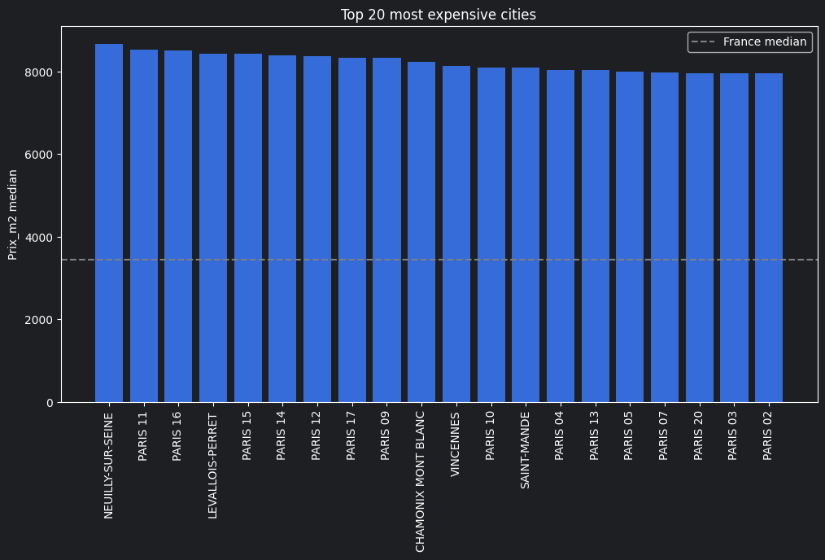

```python
top_cities = city_prices.sort_values(ascending=False).head(20)

plt.figure(figsize=(12, 6))

plt.bar(top_cities.index, top_cities.values)
plt.axhline(df_core["prix_m2"].median(), label="France median" ,color="grey", linestyle="dashed")

plt.xticks(rotation=90)
plt.ylabel("Prix_m2 median")
plt.title("Top 20 most expensive cities")

plt.legend(loc="upper right")

plt.show()
```

### Prix_m2 by `departement`

```python
core_dept_counts = df_core["Code departement"].value_counts()
```

```python
treshold_core_dept_count = core_dept_counts.quantile(0.9)
valid_dept = core_dept_counts[core_dept_counts >= treshold_core_dept_count].index

df_core_dept = df_core[df_core["Code departement"].isin(valid_dept)]
print(len(valid_dept))
```

```
10
```

```python
core_dept_prices = (
    df_core_dept.groupby("Code departement")["prix_m2"]
    .median()
    .sort_values(ascending=False)
)

core_dept_prices.sort_values(ascending=False).head(20)
```

```
Code departement
75    8157.894737
92    6200.000000
06    4777.777778
94    4707.936508
83    3809.523810
69    3800.000000
33    3636.363636
34    3545.454545
13    3476.615629
31    2993.333333
Name: prix_m2, dtype: float64
```

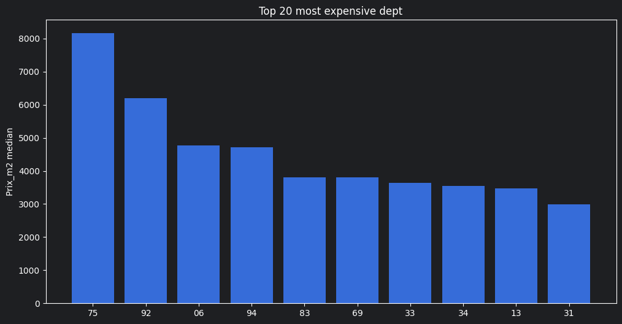

```python
core_top_dept = core_dept_prices.head(20)

plt.figure(figsize=(12, 6))

plt.bar(core_top_dept.index, core_top_dept.values)

plt.ylabel("Prix_m2 median")
plt.title("Top 20 most expensive dept")

plt.show()
```

### Prix_m2 by `departement` and `type local`

```python
df_core_dept_type = df_core.groupby(
    ["Code departement", "Type local"]
)["prix_m2"].median()
df_core_dept_type
```

```
Code departement  Type local
01                Appartement                                 3005.555556
                  Local industriel. commercial ou assimilé    2647.433628
                  Maison                                      2996.239837
02                Appartement                                 2054.411765
                  Local industriel. commercial ou assimilé    3578.542971
                                                                 ...
973               Local industriel. commercial ou assimilé    3666.666667
                  Maison                                      3080.852911
974               Appartement                                 2913.264925
                  Local industriel. commercial ou assimilé    3601.167042
                  Maison                                      2937.594268
Name: prix_m2, Length: 291, dtype: float64
```

### Temporal analysis

```python
monthly_core_transactions = (
    df_core["Date mutation"]
    .dt.month
    .value_counts()
    .sort_index()
)
print(monthly_core_transactions)
```

```
Date mutation
1     26354
2     26336
3     33887
4     31866
5     25634
6     34775
7     40084
8     22999
9     35903
10    33081
11    25956
12    35321
Name: count, dtype: int64
```

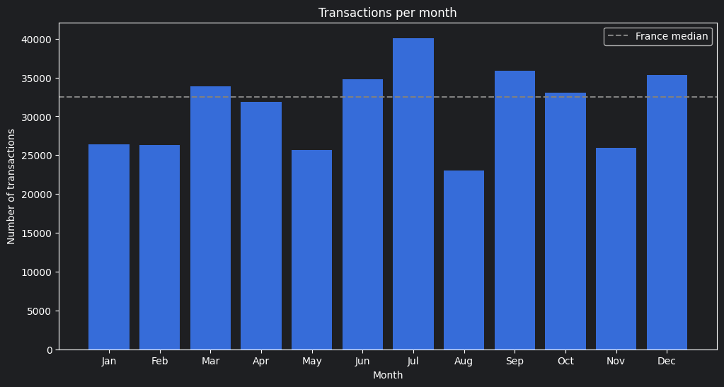

```python
months = range(1, 13)
month_names = [calendar.month_abbr[m] for m in months]

plt.figure(figsize=(12, 6))

plt.bar(
    monthly_core_transactions.index,
    monthly_core_transactions.values
)

plt.axhline(np.median(monthly_core_transactions, axis=0), label="France median" ,color="grey", linestyle="dashed")

plt.title("Transactions per month")
plt.xlabel("Month")
plt.xticks(months, month_names)
plt.ylabel("Number of transactions")

plt.legend(loc="upper right")

plt.show()
```

```python
monthly_core_prices = (
    df_core.groupby(df["Date mutation"].dt.month)["prix_m2"]
    .median()
)
print(monthly_prices)
```

```
Date mutation
1     3395.348837
2     3315.000000
3     3512.884375
4     3265.306122
5     3350.000000
6     3480.000000
7     3513.698630
8     3309.307359
9     3553.191489
10    3449.285714
11    3428.571429
12    3615.384615
Name: prix_m2, dtype: float64
```

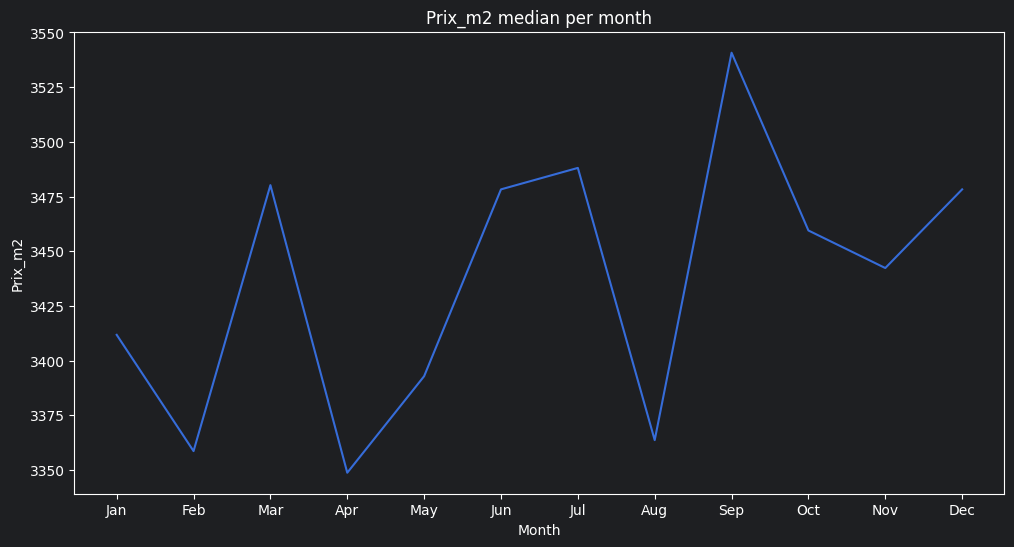

```python
plt.figure(figsize=(12, 6))

plt.plot(
    monthly_core_prices.index,
    monthly_core_prices.values
)

plt.title("Prix_m2 median per month")
plt.xlabel("Month")
plt.xticks(months, month_names)
plt.ylabel("Prix_m2")

plt.show()
```

### `Surface reelle bati` analysis

```python
df_core["Surface reelle bati"].describe()
```

```
count    372196.000000
mean         60.366613
std          77.743003
min           1.000000
25%          37.000000
50%          55.000000
75%          73.000000
max       21073.000000
Name: Surface reelle bati, dtype: float64
```

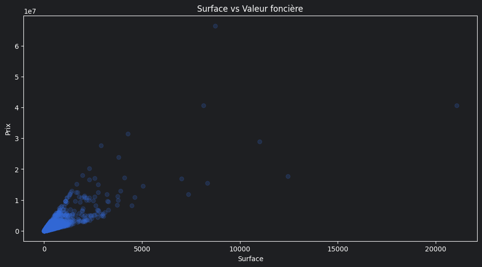

```python
plt.figure(figsize=(12, 6))

plt.scatter(
    df_core["Surface reelle bati"],
    df_core["Valeur fonciere"],
    alpha=0.2
)

plt.title("Surface vs Valeur foncière")
plt.xlabel("Surface")
plt.ylabel("Prix")

plt.show()
```

### Correlations

```python
numeric_cols = df_core[["Valeur fonciere", "Surface reelle bati", "Nombre pieces principales", "prix_m2"]]

print(numeric_cols.corr(method="spearman"))
```

```
                           Valeur fonciere  Surface reelle bati  \
Valeur fonciere                   1.000000             0.631131
Surface reelle bati               0.631131             1.000000
Nombre pieces principales         0.457581             0.737290
prix_m2                           0.558415            -0.228680

                           Nombre pieces principales   prix_m2
Valeur fonciere                             0.457581  0.558415
Surface reelle bati                         0.737290 -0.228680
Nombre pieces principales                   1.000000 -0.161370
prix_m2                                    -0.161370  1.000000
```

|  | Before | After |
| --- | --- | --- |
| 1st Factor | `prix_m2` | `Surface reelle bati` |
| 2nd Factor | `Surface reelle bati` | `prix_m2` |
| 3rd Factor | `Nombre pieces principales` | `Nombre pieces principales` |

The number of parts influences the price well, however :

- not in a linear way
- rather progressive
- 1st factor : `Surface reelle bati`
- 2nd factor : price/m² (`prix_m2`)
- 3rd factor : number of rooms (`Nombre pieces principales`)

Some remarks :

- *Surface ↔ prix_m2* and *Nombre pieces ↔ prix_m2* : The larger the properties are, the more the price/m² tends to decrease
- The `Surface` is more important
- The `Nombre pieces principales` matters
- Large properties have a lower price/m²
- The **real estate market is non-linear**

Real estate variables are strongly related, but according to non-linear relationships. The built area appears as a major factor in land value, while the number of rooms also plays a significant role. Large properties, however, tend to have a lower price per square meter.

```python
df_core.sort_values(
    by="Valeur fonciere",
    ascending=False
)[[
    "Commune",
    "Type local",
    "Valeur fonciere",
    "Surface reelle bati",
    "prix_m2"
]].head(20)
```

|  | Commune | Type local | Valeur fonciere | Surface reelle bati | prix_m2 |
| --- | --- | --- | --- | --- | --- |
| 428334 | PARIS 17 | Local industriel. commercial ou assimilé | 66534632.00 | 8736.0 | 7616.143773 |
| 265835 | CALUIRE ET CUIRE | Local industriel. commercial ou assimilé | 40744000.00 | 21073.0 | 1933.469368 |
| 445460 | PARIS 08 | Local industriel. commercial ou assimilé | 40670610.95 | 8130.0 | 5002.535172 |
| 262545 | ECULLY | Local industriel. commercial ou assimilé | 31535000.00 | 4284.0 | 7361.111111 |
| 301276 | GRAND QUEVILLY (LE) | Local industriel. commercial ou assimilé | 28900000.00 | 11000.0 | 2627.272727 |
| 460159 | PARIS 15 | Local industriel. commercial ou assimilé | 27650000.00 | 2908.0 | 9508.253095 |
| 370314 | MASSY | Local industriel. commercial ou assimilé | 23885684.00 | 3816.0 | 6259.351153 |
| 430620 | PARIS 08 | Local industriel. commercial ou assimilé | 20226696.00 | 2318.0 | 8725.925798 |
| 143606 | MONTPELLIER | Local industriel. commercial ou assimilé | 18000000.00 | 1952.0 | 9221.311475 |
| 400100 | ROSNY-SOUS-BOIS | Local industriel. commercial ou assimilé | 17707622.78 | 12440.0 | 1423.442346 |
| 193788 | NANTES | Local industriel. commercial ou assimilé | 17151000.00 | 4095.0 | 4188.278388 |
| 450384 | PARIS 15 | Local industriel. commercial ou assimilé | 17000000.00 | 2590.0 | 6563.706564 |
| 86976 | CREYSSE | Local industriel. commercial ou assimilé | 16959372.00 | 7030.0 | 2412.428450 |
| 430627 | PARIS 08 | Local industriel. commercial ou assimilé | 16658303.00 | 2318.0 | 7186.498274 |
| 232571 | SENLIS | Local industriel. commercial ou assimilé | 15500000.00 | 8337.0 | 1859.181960 |
| 379803 | NANTERRE | Local industriel. commercial ou assimilé | 15097200.00 | 1653.0 | 9133.212341 |
| 55573 | MARSEILLE 11EME | Local industriel. commercial ou assimilé | 15000000.00 | 2766.0 | 5422.993492 |
| 66274 | AIX EN PROVENCE | Local industriel. commercial ou assimilé | 14490000.00 | 5044.0 | 2872.720063 |
| 31370 | CANNES | Local industriel. commercial ou assimilé | 13000000.00 | 3891.0 | 3341.043434 |
| 204489 | ANGERS | Local industriel. commercial ou assimilé | 13000000.00 | 1419.0 | 9161.381254 |